# Manhattan Plots

Download a copy of the vignette to follow along here: manhattan_plots.Rmd

Manhattan plots can be quickly visualize the relationships between features and cluster solutions.

There are three main Manhattan plot variations provided in metasnf.

1. `esm_manhattan_plot` Visualize how a set of cluster solutions separate over input/out-of-model features
2. `mc_manhattan_plot` Visualize how representative solutions from defined meta clusters separate over input/out-of-model features
3. `var_manhattan_plot` Visualize how one raw feature associates with other raw features (similar to `assoc_pval_heatmap`)

## Data set-up

The example below is taken from the [“complete example” vignette](https://branchlab.github.io/metasnf/articles/a_complete_example.html).

```r
library(metasnf)

# Start by making a data list containing all our data frames to more easily
# identify observations without missing data
full_dl <- data_list(
    list(subc_v, "subcortical_volume", "neuroimaging", "continuous"),
    list(income, "household_income", "demographics", "continuous"),
    list(pubertal, "pubertal_status", "demographics", "continuous"),
    list(anxiety, "anxiety", "behaviour", "ordinal"),
    list(depress, "depressed", "behaviour", "ordinal"),
    uid = "unique_id"
)

# Partition into a data and target list (optional)
dl <- full_dl[1:3]
target_dl <- full_dl[4:5]

# Build space of settings to cluster over
set.seed(42)
sc <- snf_config(
    dl = dl,
    n_solutions = 20,
    min_k = 20,
    max_k = 50
)

# Clustering
sol_df <- batch_snf(dl, sc)

# Calculate p-values between cluster solutions and features
ext_sol_df <- extend_solutions(
    sol_df,
    dl = dl,
    target = target_dl,
    min_pval = 1e-10 # p-values below 1e-10 will be thresholded to 1e-10
)
```

## Associations with Multiple Cluster Solutions (`esm_manhattan_plot`)

[figure not shown]

```r
esm_manhattan <- esm_manhattan_plot(
    ext_sol_df[1:5, ],
    neg_log_pval_thresh = 5,
    threshold = 0.05,
    point_size = 3,
    jitter_width = 0.1,
    jitter_height = 0.1,
    plot_title = "Feature-Solution Associations",
    text_size = 14,
    bonferroni_line = TRUE
)
```

A bit of an unwieldy plot if you try looking at too many solutions at a time, but it can be handy if you intend on just examining a few cluster solutions.

## Associations with Meta Clusters (`mc_manhattan_plot`)

The `mc_manhattan_plot` function can be used after meta clustering to more efficiently examine the entire space of generated cluster solutions.

[figure not shown]

```r
# Calculate pairwise similarities between cluster solutions
sol_aris <- calc_aris(sol_df)

# Extract hierarchical clustering order of the cluster solutions
meta_cluster_order <- get_matrix_order(sol_aris)

# Create a base heatmap for visual meta clustering
ari_hm <- meta_cluster_heatmap(
    sol_aris,
    order = meta_cluster_order
)

# Identify meta cluster boundaries
# This can also be by trial & error if you do not wish to use the shiny app.
shiny_annotator(ari_hm)

# Result of meta cluster examination
split_vec <- c(2, 5, 12, 16)

# Create a base heatmap for visual meta clustering
ari_hm <- meta_cluster_heatmap(
    sol_aris,
    order = meta_cluster_order,
    split_vector = split_vec
)

ari_hm

# Label meta clusters based on the split vector
mc_sol_df <- label_meta_clusters(
    sol_df = ext_sol_df,
    split_vector = split_vec,
    order = meta_cluster_order
)

# Extracting representative solutions from each defined meta cluster
rep_solutions <- get_representative_solutions(sol_aris, mc_sol_df)

mc_manhattan <- mc_manhattan_plot(
    rep_solutions,
    dl = dl,
    target_dl = target_dl,
    point_size = 3,
    text_size = 12,
    plot_title = "Feature-Meta Cluster Associations",
    threshold = 0.05,
    neg_log_pval_thresh = 5
)
```

## Associations with a Key Feature

You can also visualize associations with a specific feature of interest rather than cluster solutions.

The only thing needed for this plot is a data_list - no clustering necessary.

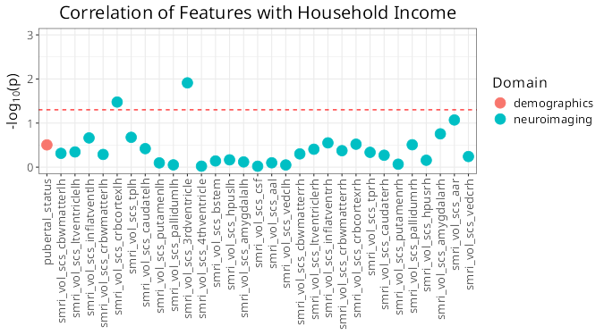

```r
var_manhattan <- var_manhattan_plot(
    dl,
    key_var = "household_income",
    plot_title = "Correlation of Features with Household Income",
    text_size = 16,
    neg_log_pval_thresh = 3,
    threshold = 0.05
)
```